# Golf Club Distance Comparison

Author

Jackson Justice

## Data

The goal of this experiment is to determine whether the type of golf club affects the distance a golf ball travels. Specifically, the question is whether the average distance differs between a 7-iron, 9-iron, and pitching wedge when struck by the same golfer under similar conditions.

The response variable is total_distance, which represents the total distance (carry + roll) in yards for each shot. This is a quantitative variable.

The factor is club, a categorical variable with three levels: 7i, 9i, and PW. These were chosen because they are common mid-to-short irons that differ in loft and shaft length, which directly influence launch speed and distance.

Each club was used for five swings, resulting in 15 total observations. The trial order was randomized to avoid any systematic bias from fatigue or warm-up effects. All swings were hit by the same golfer, using the same balls, on the same range bay, under consistent conditions. Distances were recorded after each shot without excluding mishits to maintain unbiased results.

**Why 15 observations?**  
We used 5 swings per club (3 clubs × 5 = 15 shots) to balance precision and practicality. Five replicates per group give a reasonable estimate of the mean and within-club variability in a single range session without over-fatiguing the golfer or changing conditions.

**How randomization was used**  
Before hitting, I randomized the entire 15-shot sequence so clubs were interleaved (not all 7-iron shots in a row, etc.). This spreads any time-related effects (warm-up, rhythm, breeze shifts) across clubs and supports the independence assumption.

## Import

```r
library(tidyverse)
golf <- read_csv("golf_distances.csv")
golf
```

```
# A tibble: 15 × 3
   trial club  total_distance
   <dbl> <chr>          <dbl>
 1     1 9i               134
 2     2 PW               111
 3     3 7i               150
 4     4 9i               126
 5     5 7i               154
 6     6 PW               112
 7     7 7i               157
 8     8 9i               136
 9     9 PW               108
10    10 7i               152
11    11 PW               115
12    12 9i               133
13    13 7i               149
14    14 9i               132
15    15 PW               116
```

## Wrangling

We specify the factor levels for `club` and ensure rows are in trial order.

```r
golf <- golf |>
  mutate(
    club = factor(club, levels = c("7i", "9i", "PW"))
  ) |>
  arrange(trial)

# check to make sure it worked
golf |>
  count(club)
```

```
# A tibble: 3 × 2
  club      n
  <fct> <int>
1 7i        5
2 9i        5
3 PW        5
```

```r
# summary table
summary(golf$total_distance)
```

```
   Min. 1st Qu.  Median    Mean 3rd Qu.    Max.
  108.0   115.5   133.0   132.3   149.5   157.0
```

## EDA

A summary of the distances for each club shows the mean and variability across groups.

```r
golf |>
  group_by(club) |>
  summarize(
    n = n(),
    mean = mean(total_distance),
    sd = sd(total_distance)
  )
```

```
# A tibble: 3 × 4
  club      n  mean    sd
  <fct> <int> <dbl> <dbl>
1 7i        5  152.  3.21
2 9i        5  132.  3.77
3 PW        5  112.  3.21
```

A boxplot visualizes the distribution of distances by club.

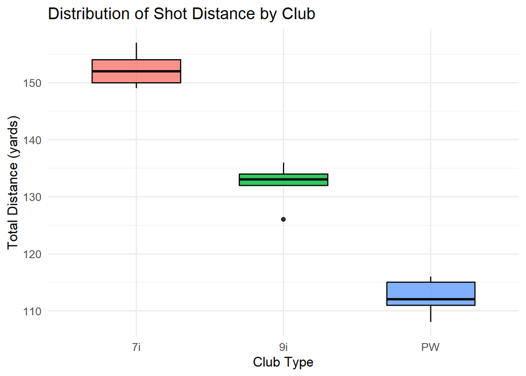

```r
ggplot(golf, aes(x = club, y = total_distance, fill = club)) +
  geom_boxplot(alpha = 0.8, width = 0.6, color = "black") +
  labs(
    x = "Club Type",
    y = "Total Distance (yards)",
    title = "Distribution of Shot Distance by Club"
  ) +
  theme_minimal(base_size = 13) +
  theme(
    legend.position = "none"
  )
```

## Modeling

An ANOVA model was fit to test whether mean distance differs among the three clubs.

```r
model <- aov(total_distance ~ club, data = golf)
anova(model)
```

```
Analysis of Variance Table

Response: total_distance
          Df Sum Sq Mean Sq F value    Pr(>F)
club       2 4000.1  2000.1  172.42 1.446e-09 ***
Residuals 12  139.2    11.6
---
Signif. codes:  0 '***' 0.001 '**' 0.01 '*' 0.05 '.' 0.1 ' ' 1
```

## Summary

The mean total distances for each club were approximately:

- 7i: 152.4 yards
- 9i: 132.2 yards
- PW: 112.4 yards

The one-way ANOVA tested whether the average distance differs by club type. The F-statistic was large with a p-value less than 0.05, indicating a statistically significant difference in mean total distance among the three clubs.

This provides evidence that the type of club affects how far the ball travels. In practical terms, the 7-iron produced the greatest average distance, followed by the 9-iron, and then the pitching wedge. This is consistent with expectations based on club loft and design.